# Processing LC MS Data

Pietro Franceschi | pietro.franceschi@fmach.it

## What is `xcms`

Framework for processing and visualization of chromatographically separated and single-spectra mass spectral data.

[xcms](http://www.bioconductor.org/packages/release/bioc/html/xcms.html)

and still growing …

[RforMassSpectrometry](https://www.rformassspectrometry.org/)

[figure not shown]

## Outline

- Data analysis, organization and data matrices
- Some thoughts on validation
- Preprocessing and analytical variability
- MS for Dummies
- LC-MS data handling
- Demo & DIY
- Peak Picking in `xcms`
- Demo & DIY
- Retention time correction and features definition
- Demo & DIY
- Dealing with Fragmentation esperiments
- Demo & DIY

## The data matrix

[figure not shown]

## The role of Data Analysis

Statistics, Bionformatics, Machine Learning, Chemometrics, …, provide the tools to:

- make science shared and reproducible … ;-)
- process and organize **big data** into the matrix
- identify the presence of **organization** in the data matrix
- assess the confidence that our result is true “at the population level”

## Examples of Organization

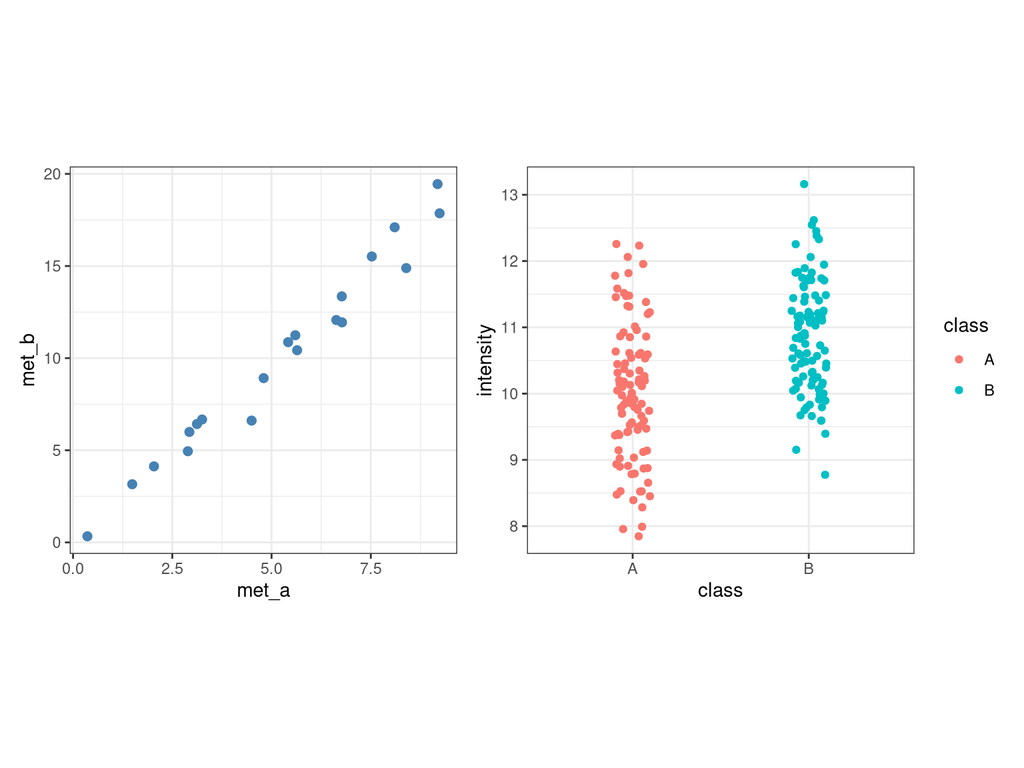

## False Positives

- Organization can show up only by chance
- These results are *true*, but the hold only for the data we are analyzing now
- Organization is not necessarily science
- Variability causes this
- We need to *validate* our outcomes

## On Validation

- **Statistical Validation**: get brand new samples and see if what we get is still there
- **Domain Validation**: is what I’m getting in keeping with the domain specific body of knowledge? Could I design an experiment to check my hypothesis?

#### Do we always need statistics?

## Data hygiene

- Go for a scripting language and forget Excel
- … at least use a gui pipeline or a web based solution
- Organize data and metadata
- Avoid as much as possible *manual curation*
- Share your data, your scripts, your results
- Go open source

## Get out your data

- Metabolomics data are always stored in “formats” which are specifically developed by instrument vendors
- In the case of MS data several open source standards are available (cdf, mzML, mzML, …)

[Proteowizard](https://proteowizard.sourceforge.io/)

- command line tool
- gui application
- docker with proprietary libraries

## LC-MS For Dummies

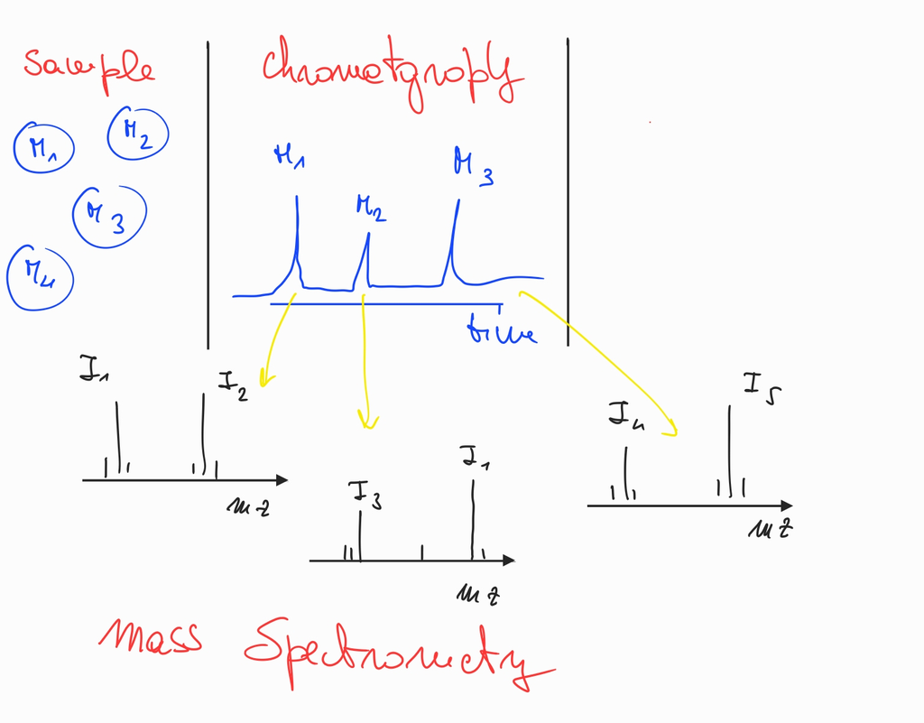

## Analytical Variability in LC-MS | Mass

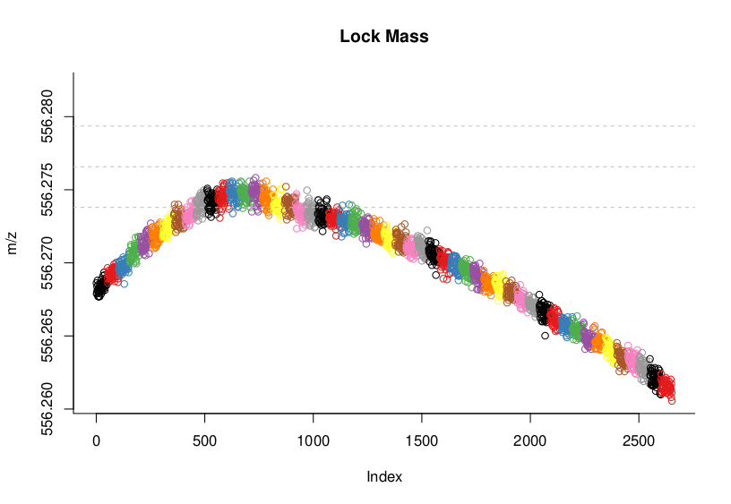

## Analytical Variability in LC-MS | Retention time

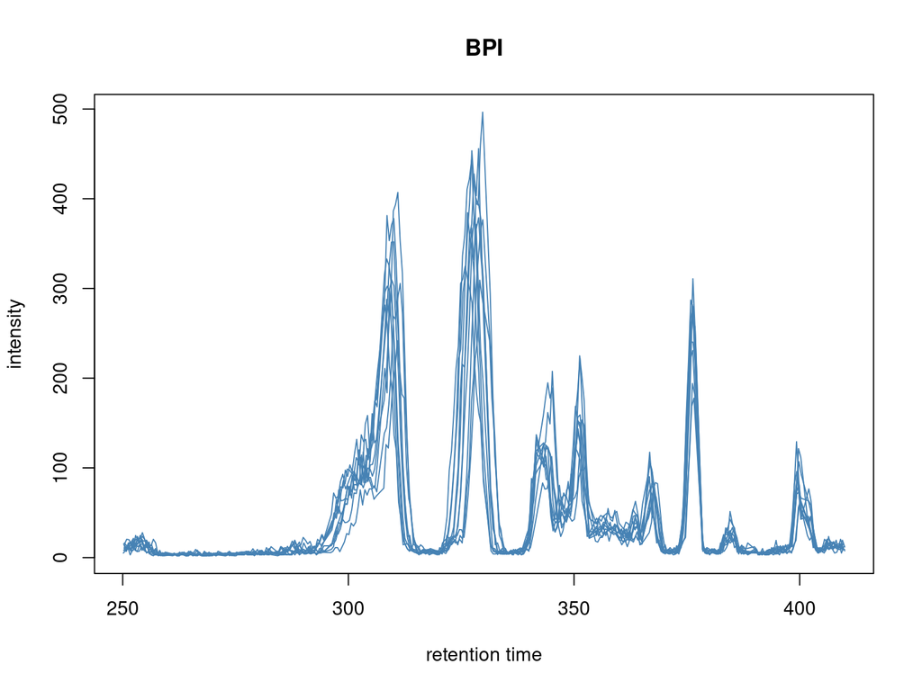

## Analytical Variability in LC-MS | Intensity

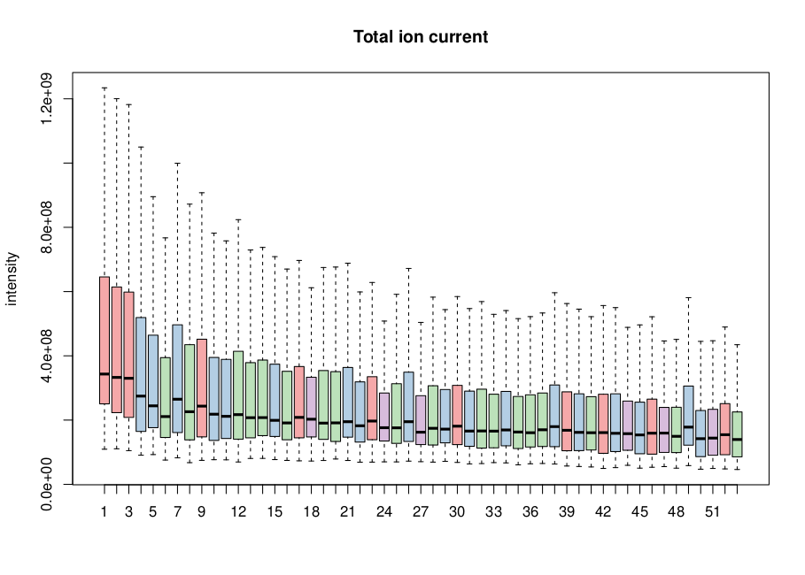

## Preprocessing

- I call **preprocessing** all the data carpentry steps I do to go from the raw experimental data to the data matrix
- The aim of this process is to compensate for *analytical variability* being able to reliably build a data matrix
- *QC samples* play a big role on that because they are sensitive only to analytical variability

## Uses of QCs

*QCs should be representative of the chemical complexity of your samples*

- correct for retention time shifts
- identify reliable variables:
  - variance in QC should be smaller than in samples
  - their intensity should decrease during dilution
  - …
- help in correcting for bath effects …

## LC-MS produces 3D data | (rt,mz,I)

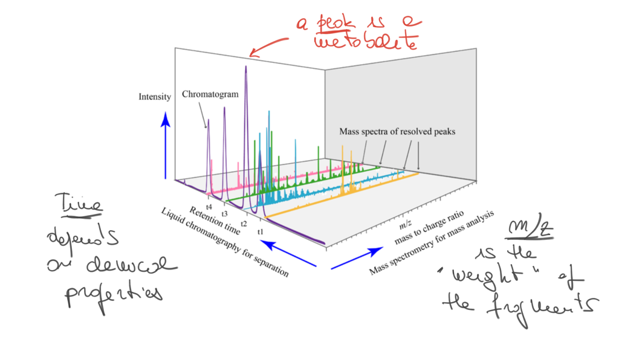

**Things too look at**

- Extracted Ion Trace/Current (EIT/EIC)
- Mass Spectra

## Extracted ion traces

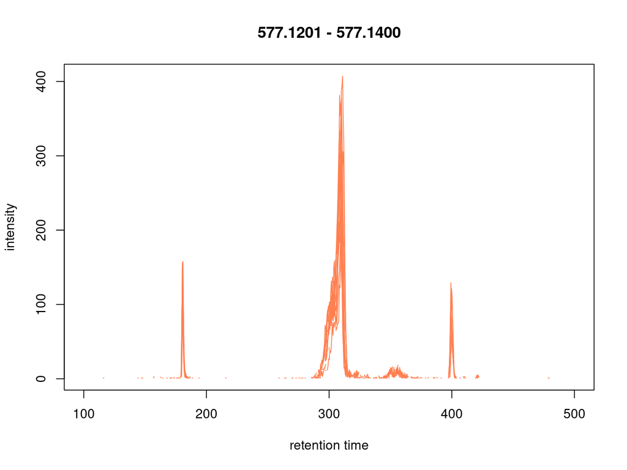

## Mass Spectra

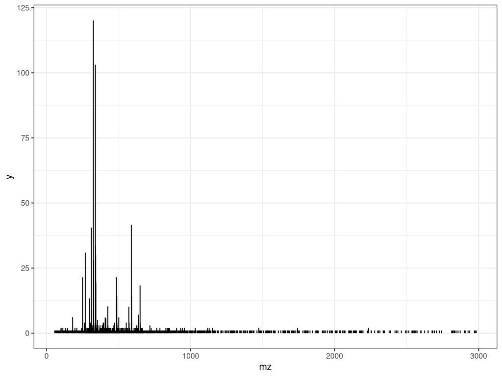

## Back to Raw data

Always check your results on the raw data

- problems in preprocessing
- bad peaks
- biomarkers
- results hidden in noise

## Hands-on: let’s switch to RStudio

# Peak Picking

## Peaks and metabolites: facts

- A **metabolite produces peaks** in the extracted ion traces of its associated ions
- Different peaks in the same ion chromatograms are associated to different metabolites
- **Peaks are not metabolites**
- The same peak can slightly **move** across the injections

**We need an automatic method to look for peaks**

## MatchedFilter

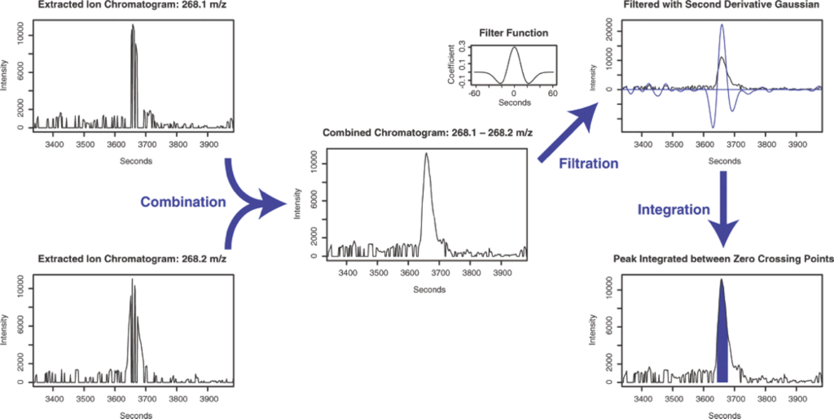

Anal Chem 2006 1;78(3):779-87. doi: 10.1021/ac051437y

## Cent Wave

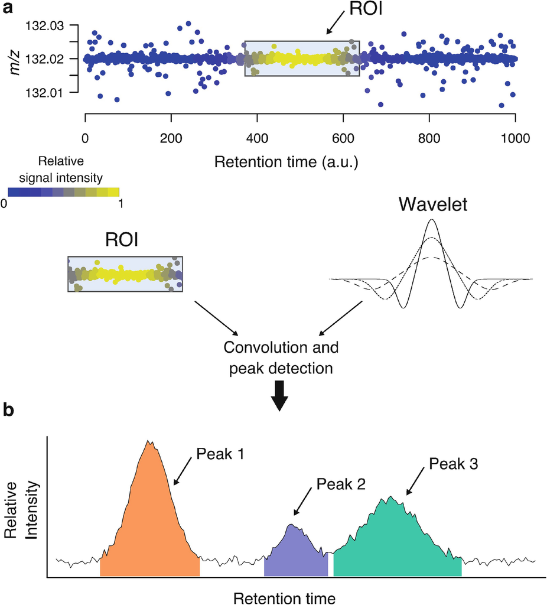

BMC Bioinformatics 9, 504 (2008). https://doi.org/10.1186/1471-2105-9-504

## Peak Intensity: `into` and `maxo`

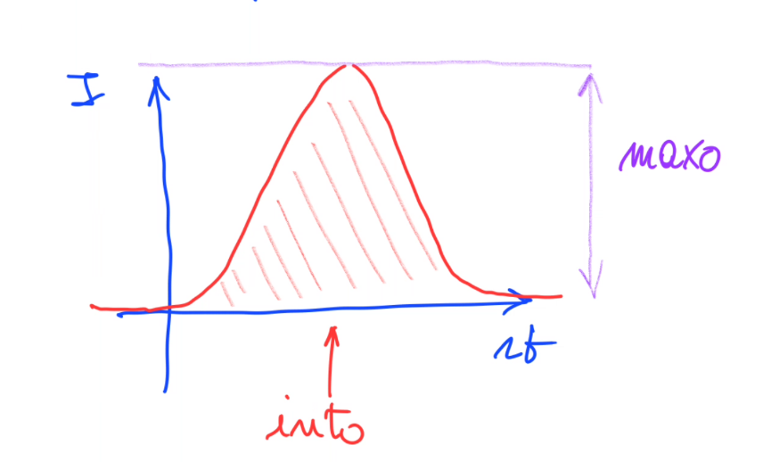

## Things to always consider

- Real peaks can be really badly shaped
- You are better than an algorithm … maybe AI will do well
- Every algorithm has parameters to tune!
- Look to the data!
- Know how the instrument works
- Check what happens to metabolites you know should be there

## Hands-on: let’s switch to RStudio

# Retention time correction and feature definition

## … Just a recap

1. We converted the data files in an open source format (here mzML)
2. We optimized the peak picking parameters working on a representative sample (QC)
3. We have been running peak picking on the full set of samples
4. We have been saving the output somewhere, just to avoid re-starting from scratch ;-)

## What Next

We have to merge the lists of chromatographic peaks into a consensus list of features peaks, which will be the columns of our data matrix

- *chromatographich peaks* what was detected in the individual samples (mz, rt, intensity)
- *features* consensus variables which are *grouping* several peaks coming from the different injections (mz, rt, intensity)

## Grouping - Correspondence

[figure not shown]

## Grouping - Correspondence

[figure not shown]

## Dynamic Time Warping

Available in `xcms` through `obiwarp`

[figure not shown]

## RT Checks

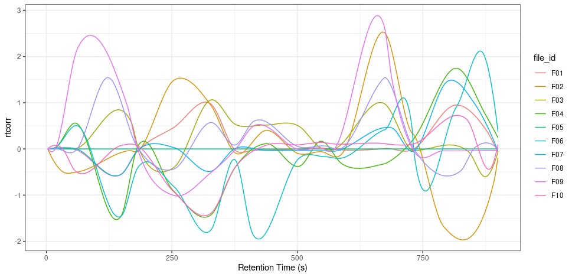

## Things to always consider

- Aligning samples and not QCs can be tricky
- Some metabolites could not be present in pooled QC (dilutions)
- Sometimes chromatographic peaks are missed
- Always check the data and the known peaks!
- Parameters are easier to tune if you know how the analytics works
- Rt shifts should be smaller than peak width

## NAssss NAssss

Even if you do everything well your final data matrix will be full of missing values:

- errors in peak picking
- “absence” of a metabolite in one or more samples (biology)
- that metabolite is below the detection limit (analytics)
- missing at random
- missing not at random

## Hands-on: let’s switch to RStudio

# Fragmentation Data

## Annotation and MS

- At the end of the journey we would like to work on *metabolites* or *pathways* and not on features
- We know that **annotation** is the most challenging step of all the business
- The more we know about the structure of our ions the better it is
- Database of standards, web resources, chemoinformatics, …
- **Fragmentation patterns are extremely useful**

## MS/MS and DDA

*DDA*: Data Dependent Acquisition

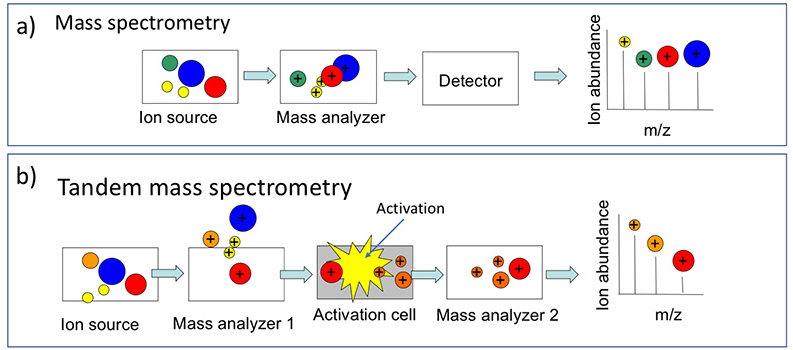

## Notes

- `xcms` allows also to handle fragmentation experiments
- `xcms` ecosystem is growing towards databases of spectra
- As we already discussed, do not be too optimistic with complex MS experiments
- Sometimes the ion you are interested was not fragmented (plan a specific run!)

## Hands-on: let’s switch to RStudio